# Practical Machine Learning Course Project

Sharvari A V

December 3, 2017

## Introduction

Using devices such as Jawbone Up, Nike FuelBand, and Fitbit it is now possible to collect a large amount of data about personal activity relatively inexpensively. These type of devices are part of the quantified self movement – a group of enthusiasts who take measurements about themselves regularly to improve their health, to find patterns in their behavior, or because they are tech geeks. One thing that people regularly do is quantify how much of a particular activity they do, but they rarely quantify how well they do it.

In this project, we will use data from accelerometers on the belt, forearm, arm, and dumbell of 6 participants to predict the manner in which they did the exercise.This is the “classe” variable in the training set.

And the `classe` variable has 5 levels:

A: exactly according to the specification B: throwing the elbows to the front C: lifting the dumbbell only halfway D: lowering the dumbbell only halfway E: throwing the hips to the front

## Data Processing

Loading the required packages for the analysis and downloading the training and testing data from the below urls:

#### Data sources

The training data for this project are available here:

https://d396qusza40orc.cloudfront.net/predmachlearn/pml-training.csv

The test data are available here:

https://d396qusza40orc.cloudfront.net/predmachlearn/pml-testing.csv

The data for this project come from this source: http://groupware.les.inf.puc-rio.br/har.

```r
library(caret)
library(rattle)
library(rpart)
library(randomForest)
library(rpart.plot)
```

#### Data Loading and cleaning

```r
trainurl <- "https://d396qusza40orc.cloudfront.net/predmachlearn/pml-training.csv"
testurl <- "https://d396qusza40orc.cloudfront.net/predmachlearn/pml-testing.csv"
trainFile <- read.csv(url(trainurl), na.strings = c("", "NA"))
testFile <- read.csv(url(testurl), na.strings = c("", "NA"))
dim(trainFile)
```

```
## [1] 19622   160
```

```r
dim(testFile)
```

```
## [1]  20 160
```

By looking at the training and testing data set, we could see that there are many variable contating missing values. Keep the variables in the training that do not have all NA’s in the test

```r
trainFile <- trainFile[,colSums(is.na(trainFile)) == 0]
testFile <- testFile[, colSums(is.na(testFile)) == 0]
#We also remove the first seven predictors since these variables have little predicting power for the outcome `classe`
trainFile <- trainFile[, -c(1:7)]
testFile <- testFile[, -c(1:7)]
dim(trainFile)
```

```
## [1] 19622    53
```

```r
dim(testFile)
```

```
## [1] 20 53
```

#### Data splitting

```r
set.seed(12345)
inTrain <- createDataPartition(trainFile$classe, p = 0.7, list = FALSE)
Train <- trainFile[inTrain,]
Test <- trainFile[-inTrain,]
dim(Train)
```

```
## [1] 13737    53
```

```r
dim(Test)
```

```
## [1] 5885   53
```

## Prediction Algorithms/Data modeling.

We will use the Train data set to build the model and first i will try with classification tree model

#### Classification tree

```r
set.seed(12345)
modTree <- train(classe ~ ., data = Train, method = "rpart")
modTree
```

```
## CART
##
## 13737 samples
##    52 predictors
##     5 classes: 'A', 'B', 'C', 'D', 'E'
##
## No pre-processing
## Resampling: Bootstrapped (25 reps)
## Summary of sample sizes: 13737, 13737, 13737, 13737, 13737, 13737, ...
## Resampling results across tuning parameters:
##
##   cp          Accuracy   Kappa
##   0.03753433  0.5073875  0.35776374
##   0.05987862  0.3869568  0.15968306
##   0.11585800  0.3335058  0.07530009
##
## Accuracy was used to select the optimal model using  the largest value.
## The final value used for the model was cp = 0.03753433.
```

Now we will predict outcome using `Test` set.

```r
prediction1 <- predict(modTree, newdata= Test)
print(confusionMatrix(prediction1, Test$classe))
```

```
## Confusion Matrix and Statistics
##
##           Reference
## Prediction    A    B    C    D    E
##          A 1494  470  467  438  141
##          B   21  380   29  184  147
##          C  128  289  530  342  277
##          D    0    0    0    0    0
##          E   31    0    0    0  517
##
## Overall Statistics
##
##                Accuracy : 0.4963
##                  95% CI : (0.4835, 0.5092)
##     No Information Rate : 0.2845
##     P-Value [Acc > NIR] : < 2.2e-16
##
##                   Kappa : 0.3425
##  Mcnemar's Test P-Value : NA
##
## Statistics by Class:
##
##                      Class: A Class: B Class: C Class: D Class: E
## Sensitivity            0.8925  0.33363  0.51657   0.0000  0.47782
## Specificity            0.6400  0.91972  0.78679   1.0000  0.99355
## Pos Pred Value         0.4963  0.49934  0.33844      NaN  0.94343
## Neg Pred Value         0.9374  0.85187  0.88516   0.8362  0.89414
## Prevalence             0.2845  0.19354  0.17434   0.1638  0.18386
## Detection Rate         0.2539  0.06457  0.09006   0.0000  0.08785
## Detection Prevalence   0.5115  0.12931  0.26610   0.0000  0.09312
## Balanced Accuracy      0.7662  0.62667  0.65168   0.5000  0.73568
```

From the above result, we could see that the accuracy rate is 49.63 % and out of sample error rate is `100 -49.63 = 50.37` i.e. 0.5 .The classification tree model does not predict the outcome `classe` well.

### Random Forest method:

```r
set.seed(12345)
model_rf <- randomForest(classe ~ . , data = Train)
model_rf
```

```
##
## Call:
##  randomForest(formula = classe ~ ., data = Train)
##                Type of random forest: classification
##                      Number of trees: 500
## No. of variables tried at each split: 7
##
##         OOB estimate of  error rate: 0.55%
## Confusion matrix:
##      A    B    C    D    E  class.error
## A 3904    1    1    0    0 0.0005120328
## B   13 2638    7    0    0 0.0075244545
## C    0   18 2372    6    0 0.0100166945
## D    0    0   21 2229    2 0.0102131439
## E    0    0    0    6 2519 0.0023762376
```

Predicting outcome `classe` using Test set.

```r
prediction2 <- predict(model_rf, newdata = Test)
rf_c <-confusionMatrix(prediction2, Test$classe)
rf_c
```

```
## Confusion Matrix and Statistics
##
##           Reference
## Prediction    A    B    C    D    E
##          A 1673   10    0    0    0
##          B    1 1126   10    0    0
##          C    0    3 1015   14    0
##          D    0    0    1  950    5
##          E    0    0    0    0 1077
##
## Overall Statistics
##
##                Accuracy : 0.9925
##                  95% CI : (0.99, 0.9946)
##     No Information Rate : 0.2845
##     P-Value [Acc > NIR] : < 2.2e-16
##
##                   Kappa : 0.9905
##  Mcnemar's Test P-Value : NA
##
## Statistics by Class:
##
##                      Class: A Class: B Class: C Class: D Class: E
## Sensitivity            0.9994   0.9886   0.9893   0.9855   0.9954
## Specificity            0.9976   0.9977   0.9965   0.9988   1.0000
## Pos Pred Value         0.9941   0.9903   0.9835   0.9937   1.0000
## Neg Pred Value         0.9998   0.9973   0.9977   0.9972   0.9990
## Prevalence             0.2845   0.1935   0.1743   0.1638   0.1839
## Detection Rate         0.2843   0.1913   0.1725   0.1614   0.1830
## Detection Prevalence   0.2860   0.1932   0.1754   0.1624   0.1830
## Balanced Accuracy      0.9985   0.9931   0.9929   0.9921   0.9977
```

## Results

Prediction on the real test set. Here we are using Random forest model `model_rf` as it showed 99% accuracy rate when compared to classification tree model which showed 49%

```r
testingPrediction <- predict(model_rf, newdata = testFile)
testingPrediction
```

```
##  1  2  3  4  5  6  7  8  9 10 11 12 13 14 15 16 17 18 19 20
##  B  A  B  A  A  E  D  B  A  A  B  C  B  A  E  E  A  B  B  B
## Levels: A B C D E
```

## Appendix

Plot for classification Tree model:

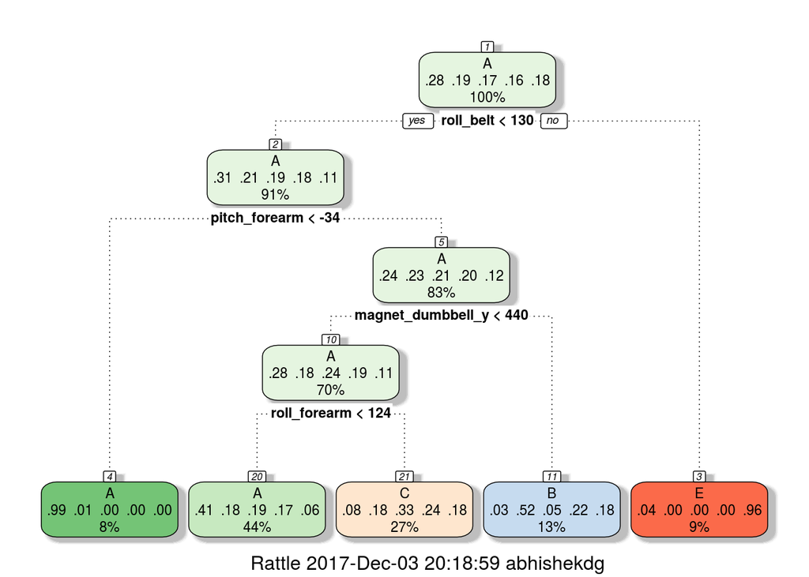

```r
fancyRpartPlot(modTree$finalModel)
```

## Conclusion

The Random forest model approach is best suited to get accurate predictions for this data. After applying the random forest model to the test set showed 99% accuray rate.